# Squid data: preliminary results

Smith B.E.

4/03/2024

1. Data wrangling $~$ $~$ $~$ $~$

```
## [1] "Numbers of stomachs"
```

```
##   svspp    size  n
## 1   502  <15 cm 23
## 2   502 >=15 cm 25
## 3   503     ALL 50
```

$~$ $~$ $~$ $~$

2. Mapping sampling locations $~$ $~$ $~$ $~$

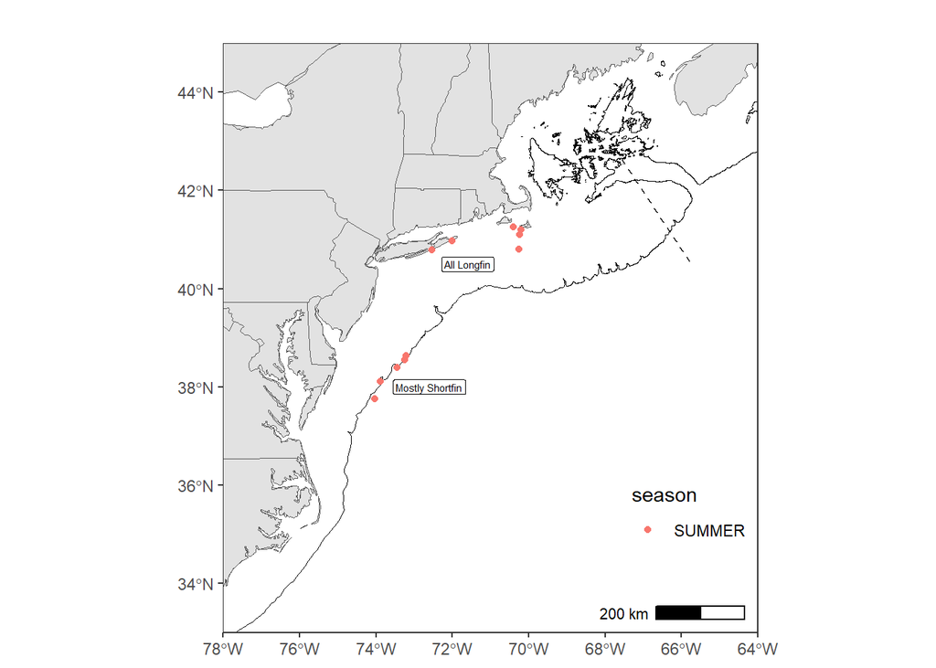

$~$ $~$ $~$ $~$

3. Percent frequency of occurrence (FO) by size (mantle length) for summer 2023 samples (prey metabarcoding) $~$ $~$ $~$ $~$

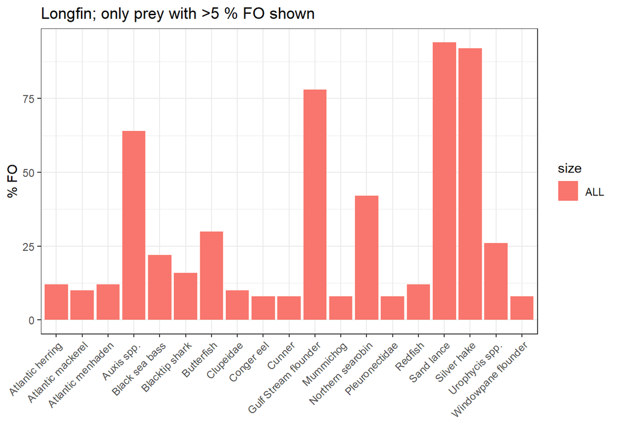

```r
#fo plots from d8
#create prey names for plots
fopy=data.frame('prey'=sort(unique(d8$prey)))
fopy2=read.csv('fopy2.csv', h=T, sep=',', na.strings = c(NA))


d9=merge(d8, fopy2, by=c('prey'), all.x=T)

lfd=subset(d9, d9$svspp==503&d9$pctfo>5) #Limited prey to those with > 5 %fo for both predators.
sfd=subset(d9, d9$svspp==502&d9$pctfo>5)

#fo barplots by svspp and size

#png('lf.size.png', height = 4, width = 6, units='in', res=600)
ggplot(lfd)+geom_bar(aes(x=prey2, y=pctfo, fill=size), stat='identity', position='dodge')+
  xlab('')+ylab('% FO')+scale_x_discrete(guide = guide_axis(angle=45))+
  ggtitle('Longfin; only prey with >5 % FO shown')#heme(axis.text.x=element_text(angle = 45, vjust = 0.5))
```

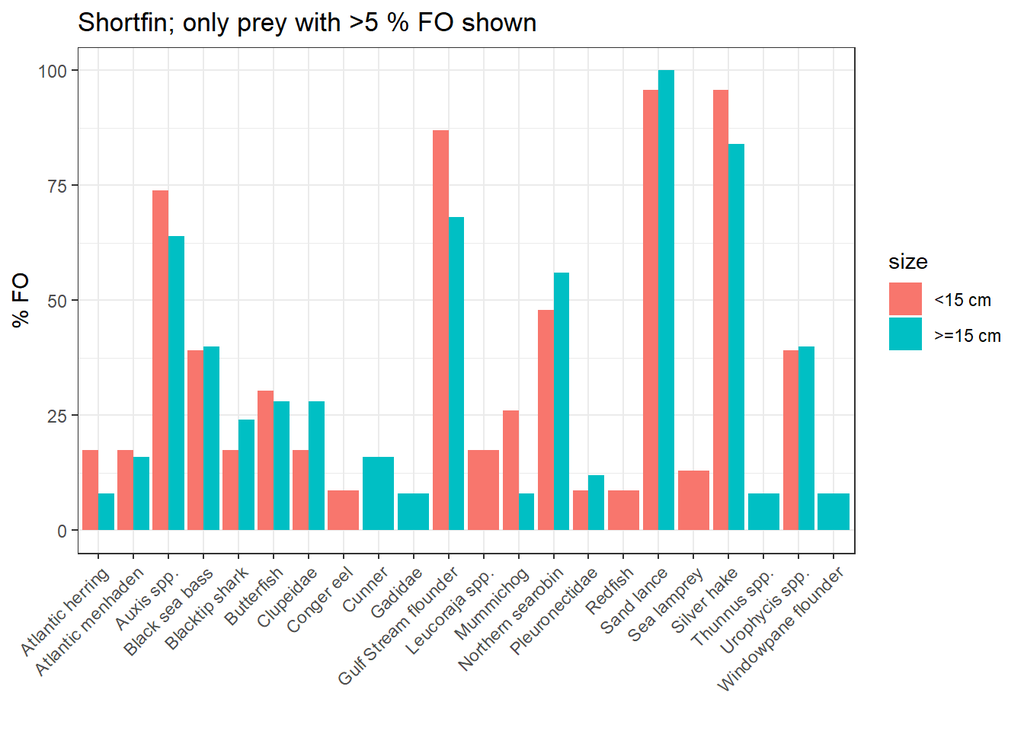

```r
#dev.off()

#png('sf.size.png', height = 4, width = 6, units='in', res=600)
ggplot(sfd)+geom_bar(aes(x=prey2, y=pctfo, fill=size), stat='identity', position='dodge')+
  xlab('')+ylab('% FO')+scale_x_discrete(guide = guide_axis(angle=45))+
  ggtitle('Shortfin; only prey with >5 % FO shown')#+theme(panel.grid.minor=element_blank(), panel.grid.major=element_blank())
```

```r
#dev.off()
```

4. BTS data from 1970s and 1980s (visual prey identification)

```r
s=read.csv('squid.allfreqp2024-04-01.csv', h=T, sep=',', na.strings = c(NA))

#bring in prey names
py24=read.csv('SASPREY24.csv', h=T, sep=',', na.strings=c(NA))
names(py24)=tolower(names(py24))
py24$prey=py24$collcat

s.=merge(s, py24[,c(12,11)], by=c('prey'), all.x=T)
s.$prey2=ifelse(s.$prey=='OTHFIS', 'Unid. fish', ifelse(s.$prey=='CEPHAL', 'Celphalopoda', ifelse(s.$prey=='BIVALV', 'Bivalvia', ifelse(s.$prey=='ILLESP','Illex sp', ifelse(s.$prey=='AR', 'AR', ifelse(s.$prey=='GASTRO', 'Gastropoda', ifelse(s.$prey=='GADFAM', 'Gadidae', paste(substr(s.$collcom, 1,1), tolower(substr(s.$collcom,2,nchar(s.$collcom)))))))))))

#plots by area, season, size.
s2=subset(s., s.$nstom>25&s.$perfrq>1&s.$prey!='EMPTY')
#s2

#unique(s2[c('pdcomnam', 'geoarea', 'season', 'size', 'nstom')])
lf=subset(s2, s2$pdcomnam=='LONGFIN SQUID')
sf=subset(s2, s2$pdcomnam=='NORTHERN SHORTFIN SQUID')

#longfin 3x3  gb-- spring, summer, fall etc.
library(ggpubr)
```

Longfin BTS; only prey with >1 % FO shown

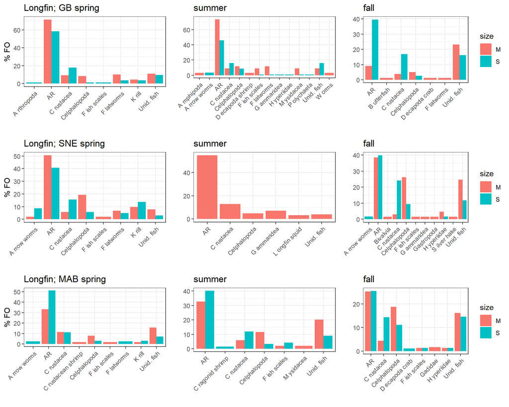

Shortfin BTS; only prey with >1 % FO shown

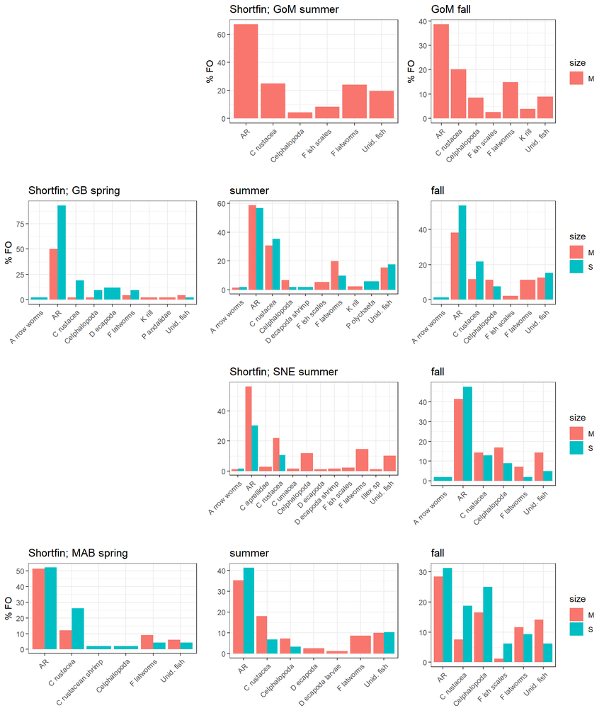

5. Predation pressure index (PPI) to highlight value of genetics for informing natural mortality in fisheries management.

Followed similar approach as [Richards and Jacobson (2016)](https://www.sciencedirect.com/science/article/abs/pii/S0165783616300595) using biomass/tow survey indices to weight percent frequency of occurrence of selected prey.

Shortfin had enough samples to look at PPI over area (SNE and MAB) and size (M, S), but I only considered area for Longfin at this stage since they were unevenly spread across SNE and MAB..

Results show that with the use of genetics in 2023, we uncovered higher predation pressure on most fishes (butterfish, silver hake, others) and this was ~ 1-2 orders of magnitude larger (2023 vs 1970s and 1980s). This was even true considering the unid. fish prey from the 1970s and 1980s. The increase was due to the genetic advantages of identifying prey, plus some increases in biomass/tow indices for these squids since the 1970s and 1980s.

To put this further into perspective, if you look at the total PPI of selected prey across groundfish with summer diet data from SNE and MAB, the added information from genetics shows we are ‘off’ by at least an order of magnitude in terms of predation pressure simply from these two squid alone.

Error bars represent 95% ci for PPI and were from simulated beta (FO) and gamma (biomass/tow) distributions based on mean and sd for FO and biomass indices.

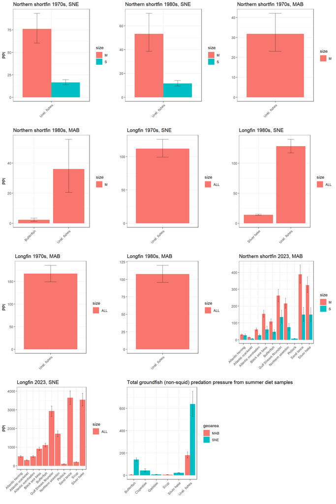

6. Ways forward?

Molecular data only apply to fish prey, so focus more on FO less on biomass.

One use of these data could be a comparison of trad vs new/non trad methods to improve ecosystem knowledge/management. There is one upcoming AFS symposium on [genomics](https://afsannualmeeting.fisheries.org/2024/03/22/interweaving-traditional-ecological-knowledge-with-genetic-genomic-approaches-for-fisheries-conservation-and-management/) which this work could connect.

Waiting for Fall 2023 BTS samples (~100) to be processed by genetics lab. Spring 2024 BTS squid currently being collected.